# Proyecto Reglas de Asociasón FCA

Tomas Lemus

17/1/2021

# Reglas de asociación

## Introducción

En el paquete fcaR usamos un dataset llamado vegas:

```r
library(fcaR)
data("vegas")
library(arules)
```

```r
library(arulesViz)
```

## Contexto formal

Creamos el contexto formal y extraemos las implicaciones

```r
fc= FormalContext$new(vegas)
print(fc)
```

```
## FormalContext with 504 objects and 25 attributes.
##        Period of stay=Dec-Feb   Period of stay=Jun-Aug   Period of stay=Mar-May
##    A1            X
##    A2            X
##    A3                                                              X
##    A4                                                              X
##    A5                                                              X
##    A6                                                              X
##    A7                                                              X
##    A8                                                              X
##    A9                                                              X
##   A10                                                              X
## Other attributes are: Period of stay=Sep-Nov, Traveler type=Business,
## Traveler type=Couples, Traveler type=Families, Traveler type=Friends, Traveler
## type=Solo, ...
```

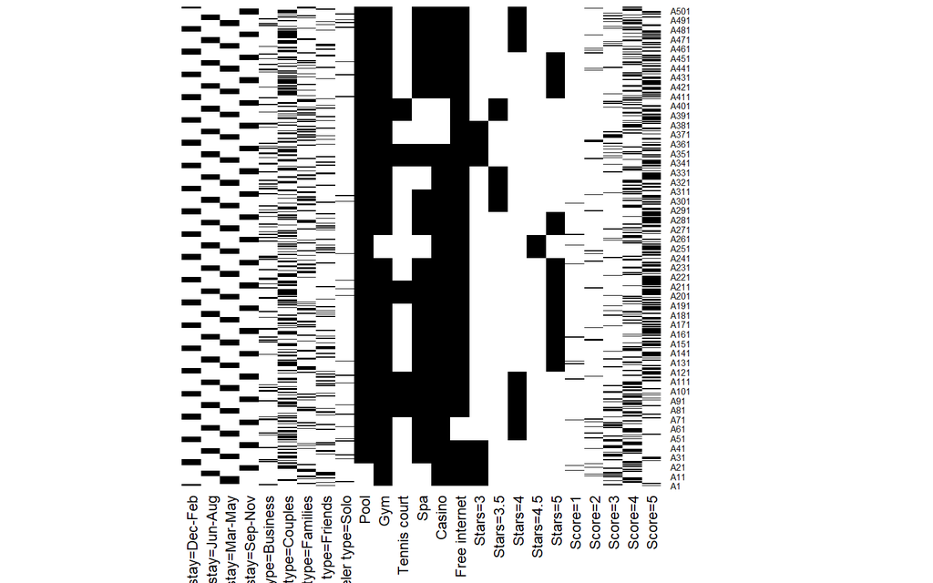

```r
plot(fc)
```

En el plot podemos visualizar en una forma simplificada los periodos de estadias, el tipode viaje, adecuaciones, estrellas y calificaciones para los hoteles en Las Vegas.

## Implicaciones

```r
fc$find_implications()
```

```r
attr_vegas = fc$attributes
head(attr_vegas)
```

```
## [1] "Period of stay=Dec-Feb" "Period of stay=Jun-Aug" "Period of stay=Mar-May"
## [4] "Period of stay=Sep-Nov" "Traveler type=Business" "Traveler type=Couples"
```

```r
obj_vegas = fc$objects
head(obj_vegas)
```

```
## [1] "A1" "A2" "A3" "A4" "A5" "A6"
```

Encontramos los conceptos y mostramos los 10 primeros

```r
conce=fc$find_concepts()
conce$dim()
```

```
## [1] 504  25
```

```r
conce$concepts[1:10]
```

```
## ({A1, A2, A3, A4, A5, A6, A7, A8, A9, A10, A11, A12, A13, A14, A15, A16,
##   A17, A18, A19, A20, A21, A22, A23, A24, A25, A26, A27, A28, A29, A30,
##   A31, A32, A33, A34, A35, A36, A37, A38, A39, A40, A41, A42, A43, A44,
##   A45, A46, A47, A48, A49, A50, A51, A52, A53, A54, A55, A56, A57, A58,
##   A59, A60, A61, A62, A63, A64, A65, A66, A67, A68, A69, A70, A71, A72,
##   A73, A74, A75, A76, A77, A78, A79, A80, A81, A82, A83, A84, A85, A86,
##   A87, A88, A89, A90, A91, A92, A93, A94, A95, A96, A97, A98, A99, A100,
##   A101, A102, A103, A104, A105, A106, A107, A108, A109, A110, A111, A112,
##   A113, A114, A115, A116, A117, A118, A119, A120, A121, A122, A123, A124,
##   A125, A126, A127, A128, A129, A130, A131, A132, A133, A134, A135, A136,
##   A137, A138, A139, A140, A141, A142, A143, A144, A145, A146, A147, A148,
##   A149, A150, A151, A152, A153, A154, A155, A156, A157, A158, A159, A160,
##   A161, A162, A163, A164, A165, A166, A167, A168, A169, A170, A171, A172,
##   A173, A174, A175, A176, A177, A178, A179, A180, A181, A182, A183, A184,
##   A185, A186, A187, A188, A189, A190, A191, A192, A193, A194, A195, A196,
##   A197, A198, A199, A200, A201, A202, A203, A204, A205, A206, A207, A208,
##   A209, A210, A211, A212, A213, A214, A215, A216, A217, A218, A219, A220,
##   A221, A222, A223, A224, A225, A226, A227, A228, A229, A230, A231, A232,
##   A233, A234, A235, A236, A237, A238, A239, A240, A241, A242, A243, A244,
##   A245, A246, A247, A248, A249, A250, A251, A252, A253, A254, A255, A256,
##   A257, A258, A259, A260, A261, A262, A263, A264, A265, A266, A267, A268,
##   A269, A270, A271, A272, A273, A274, A275, A276, A277, A278, A279, A280,
##   A281, A282, A283, A284, A285, A286, A287, A288, A289, A290, A291, A292,
##   A293, A294, A295, A296, A297, A298, A299, A300, A301, A302, A303, A304,
##   A305, A306, A307, A308, A309, A310, A311, A312, A313, A314, A315, A316,
##   A317, A318, A319, A320, A321, A322, A323, A324, A325, A326, A327, A328,
##   A329, A330, A331, A332, A333, A334, A335, A336, A337, A338, A339, A340,
##   A341, A342, A343, A344, A345, A346, A347, A348, A349, A350, A351, A352,
##   A353, A354, A355, A356, A357, A358, A359, A360, A361, A362, A363, A364,
##   A365, A366, A367, A368, A369, A370, A371, A372, A373, A374, A375, A376,
##   A377, A378, A379, A380, A381, A382, A383, A384, A385, A386, A387, A388,
##   A389, A390, A391, A392, A393, A394, A395, A396, A397, A398, A399, A400,
##   A401, A402, A403, A404, A405, A406, A407, A408, A409, A410, A411, A412,
##   A413, A414, A415, A416, A417, A418, A419, A420, A421, A422, A423, A424,
##   A425, A426, A427, A428, A429, A430, A431, A432, A433, A434, A435, A436,
##   A437, A438, A439, A440, A441, A442, A443, A444, A445, A446, A447, A448,
##   A449, A450, A451, A452, A453, A454, A455, A456, A457, A458, A459, A460,
##   A461, A462, A463, A464, A465, A466, A467, A468, A469, A470, A471, A472,
##   A473, A474, A475, A476, A477, A478, A479, A480, A481, A482, A483, A484,
##   A485, A486, A487, A488, A489, A490, A491, A492, A493, A494, A495, A496,
```

[output cut: 106 more lines]

```
##   A270, A272, A276, A284, A294, A295, A296, A301, A303, A308, A310, A312,
##   A313, A314, A317, A320, A321, A322, A333, A334, A336, A344, A350, A352,
##   A357, A372, A375, A378, A379, A380, A381, A383, A385, A390, A393, A394,
##   A398, A402, A404, A406, A407, A409, A411, A416, A417, A421, A422, A428,
##   A432, A433, A435, A444, A446, A447, A450, A452, A455, A457, A460, A463,
##   A469, A470, A473, A477, A480, A481, A483, A487, A488, A490, A491, A493,
##   A496, A501, A502, A504}, {Free internet, Score=4})
## ({A2, A6, A10, A12, A14, A15, A19, A28, A32, A33, A34, A36, A41, A42, A43,
##   A48, A73, A80, A81, A83, A89, A92, A99, A100, A106, A126, A134, A142,
##   A169, A180, A185, A190, A201, A222, A241, A259, A261, A271, A309, A331,
##   A339, A346, A348, A351, A355, A358, A361, A367, A368, A369, A370, A373,
##   A399, A403, A405, A413, A441, A464, A466, A468, A482, A484, A489, A492,
##   A495, A498}, {Free internet, Score=3})
## ({A11, A13, A20, A24, A40, A116, A154, A155, A167, A209, A237, A245, A248,
##   A290, A307, A345, A363, A364, A438, A440, A456, A459, A461, A475, A503}, {Free internet, Score=2})
```

## Retículo de conceptos

Gráfico del retículo de conceptos

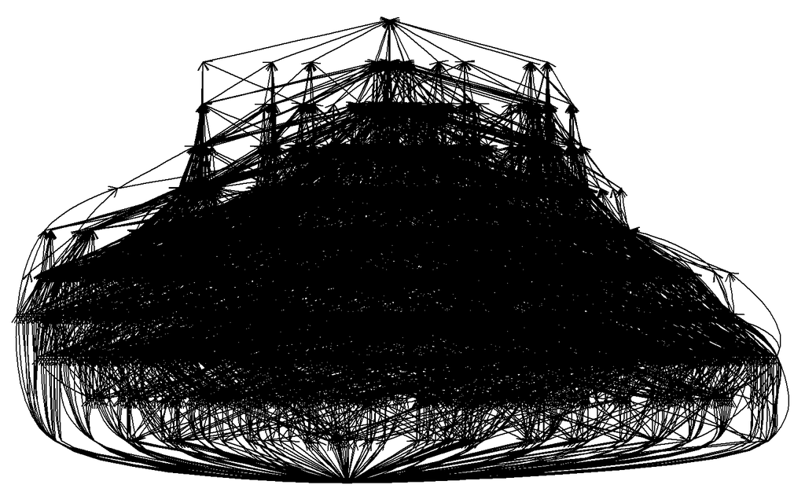

```r
conce$concepts$plot(object_names = FALSE)
```

Vamos a crear el reticulo de conceptos y una variable el subretículo con soporte mayor que 0.3.

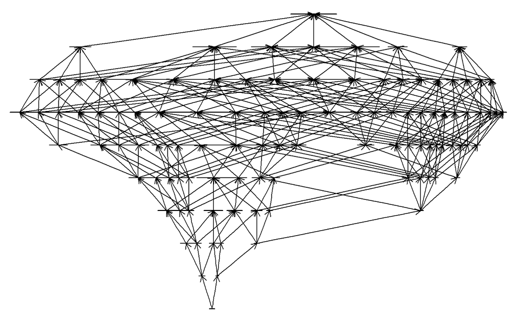

```r
idx <- which(fc$concepts$support() > 0.3)
sublattice <- fc$concepts$sublattice(idx)
sublattice$plot()
```

```r
conce$concepts$supremum(conce$dim())
```

```
## ({A1, A2, A3, A4, A5, A6, A7, A8, A9, A10, A11, A12, A13, A14, A15, A16,
##   A17, A18, A19, A20, A21, A22, A23, A24, A25, A26, A27, A28, A29, A30,
##   A31, A32, A33, A34, A35, A36, A37, A38, A39, A40, A41, A42, A43, A44,
##   A45, A46, A47, A48, A49, A50, A51, A52, A53, A54, A55, A56, A57, A58,
##   A59, A60, A61, A62, A63, A64, A65, A66, A67, A68, A69, A70, A71, A72,
##   A73, A74, A75, A76, A77, A78, A79, A80, A81, A82, A83, A84, A85, A86,
##   A87, A88, A89, A90, A91, A92, A93, A94, A95, A96, A97, A98, A99, A100,
##   A101, A102, A103, A104, A105, A106, A107, A108, A109, A110, A111, A112,
##   A113, A114, A115, A116, A117, A118, A119, A120, A121, A122, A123, A124,
##   A125, A126, A127, A128, A129, A130, A131, A132, A133, A134, A135, A136,
##   A137, A138, A139, A140, A141, A142, A143, A144, A145, A146, A147, A148,
##   A149, A150, A151, A152, A153, A154, A155, A156, A157, A158, A159, A160,
##   A161, A162, A163, A164, A165, A166, A167, A168, A169, A170, A171, A172,
##   A173, A174, A175, A176, A177, A178, A179, A180, A181, A182, A183, A184,
##   A185, A186, A187, A188, A189, A190, A191, A192, A193, A194, A195, A196,
##   A197, A198, A199, A200, A201, A202, A203, A204, A205, A206, A207, A208,
##   A209, A210, A211, A212, A213, A214, A215, A216, A217, A218, A219, A220,
##   A221, A222, A223, A224, A225, A226, A227, A228, A229, A230, A231, A232,
##   A233, A234, A235, A236, A237, A238, A239, A240, A265, A266, A267, A268,
##   A269, A270, A271, A272, A273, A274, A275, A276, A277, A278, A279, A280,
##   A281, A282, A283, A284, A285, A286, A287, A288, A289, A290, A291, A292,
##   A293, A294, A295, A296, A297, A298, A299, A300, A301, A302, A303, A304,
##   A305, A306, A307, A308, A309, A310, A311, A312, A313, A314, A315, A316,
##   A317, A318, A319, A320, A321, A322, A323, A324, A325, A326, A327, A328,
##   A329, A330, A331, A332, A333, A334, A335, A336, A337, A338, A339, A340,
##   A341, A342, A343, A344, A345, A346, A347, A348, A349, A350, A351, A352,
##   A353, A354, A355, A356, A357, A358, A359, A360, A361, A362, A363, A364,
##   A365, A366, A367, A368, A369, A370, A371, A372, A373, A374, A375, A376,
##   A377, A378, A379, A380, A381, A382, A383, A384, A385, A386, A387, A388,
##   A389, A390, A391, A392, A393, A394, A395, A396, A397, A398, A399, A400,
##   A401, A402, A403, A404, A405, A406, A407, A408, A409, A410, A411, A412,
##   A413, A414, A415, A416, A417, A418, A419, A420, A421, A422, A423, A424,
##   A425, A426, A427, A428, A429, A430, A431, A432, A433, A434, A435, A436,
##   A437, A438, A439, A440, A441, A442, A443, A444, A445, A446, A447, A448,
##   A449, A450, A451, A452, A453, A454, A455, A456, A457, A458, A459, A460,
##   A461, A462, A463, A464, A465, A466, A467, A468, A469, A470, A471, A472,
##   A473, A474, A475, A476, A477, A478, A479, A480, A481, A482, A483, A484,
##   A485, A486, A487, A488, A489, A490, A491, A492, A493, A494, A495, A496,
##   A497, A498, A499, A500, A501, A502, A503, A504}, {Gym})
```

```r
fc$concepts$infimum(conce$dim())
```

```
## ({}, {Period of stay=Dec-Feb, Period of stay=Jun-Aug, Period of stay=Mar-May,
##   Period of stay=Sep-Nov, Traveler type=Business, Traveler type=Couples,
##   Traveler type=Families, Traveler type=Friends, Traveler type=Solo,
##   Pool, Gym, Tennis court, Spa, Casino, Free internet, Stars=3, Stars=3.5,
##   Stars=4, Stars=4.5, Stars=5, Score=1, Score=2, Score=3, Score=4, Score=5})
```

Grabaremos el objeto en un fichero .rds.

```r
fc$save(filename = tempfile(fileext = ".rds"))
```

vamos a calcula lo siguientes conjuntos usando los métodos del paquete fcaR:

```r
S <- SparseSet$new(attributes = fc$attributes)
S$assign(Score = 5)
S
```

```
## {}
```

```r
S$assign(Score=3,Pool=1,Spa=1)
S
```

```
## {Pool, Spa}
```

## Implicaciones

Motramos Cuantas implicaciones se han extraido y sus 10 primeras

```r
fc$find_implications()
fc$implications$size()
```

```
##        LHS RHS
##   [1,]   2  23
##   [2,]   2  23
##   [3,]   2  23
##   [4,]   2  23
##   [5,]   2  23
##   [6,]   2  23
##   [7,]   1   1
##   [8,]   1   5
##   [9,]   1   3
##  [10,]   1   4
##  [11,]   1   3
##  [12,]   1   2
##  [13,]   3  22
##  [14,]   3  22
```

[output cut: 368 more lines]

```r
fc$implications[1:10]
```

```
## Implication set with 10 implications.
## Rule 1: {Score=4, Score=5} -> {Period of stay=Dec-Feb, Period
##   of stay=Jun-Aug, Period of stay=Mar-May, Period of stay=Sep-
##   Nov, Traveler type=Business, Traveler type=Couples, Traveler
##   type=Families, Traveler type=Friends, Traveler type=Solo, Pool,
##   Gym, Tennis court, Spa, Casino, Free internet, Stars=3, Stars=3.5,
##   Stars=4, Stars=4.5, Stars=5, Score=1, Score=2, Score=3}
## Rule 2: {Score=3, Score=5} -> {Period of stay=Dec-Feb, Period
##   of stay=Jun-Aug, Period of stay=Mar-May, Period of stay=Sep-
##   Nov, Traveler type=Business, Traveler type=Couples, Traveler
##   type=Families, Traveler type=Friends, Traveler type=Solo, Pool,
##   Gym, Tennis court, Spa, Casino, Free internet, Stars=3, Stars=3.5,
##   Stars=4, Stars=4.5, Stars=5, Score=1, Score=2, Score=4}
## Rule 3: {Score=3, Score=4} -> {Period of stay=Dec-Feb, Period
##   of stay=Jun-Aug, Period of stay=Mar-May, Period of stay=Sep-
##   Nov, Traveler type=Business, Traveler type=Couples, Traveler
##   type=Families, Traveler type=Friends, Traveler type=Solo, Pool,
##   Gym, Tennis court, Spa, Casino, Free internet, Stars=3, Stars=3.5,
##   Stars=4, Stars=4.5, Stars=5, Score=1, Score=2, Score=5}
## Rule 4: {Score=2, Score=5} -> {Period of stay=Dec-Feb, Period
##   of stay=Jun-Aug, Period of stay=Mar-May, Period of stay=Sep-
##   Nov, Traveler type=Business, Traveler type=Couples, Traveler
##   type=Families, Traveler type=Friends, Traveler type=Solo, Pool,
##   Gym, Tennis court, Spa, Casino, Free internet, Stars=3, Stars=3.5,
##   Stars=4, Stars=4.5, Stars=5, Score=1, Score=3, Score=4}
## Rule 5: {Score=2, Score=4} -> {Period of stay=Dec-Feb, Period
##   of stay=Jun-Aug, Period of stay=Mar-May, Period of stay=Sep-
##   Nov, Traveler type=Business, Traveler type=Couples, Traveler
##   type=Families, Traveler type=Friends, Traveler type=Solo, Pool,
##   Gym, Tennis court, Spa, Casino, Free internet, Stars=3, Stars=3.5,
##   Stars=4, Stars=4.5, Stars=5, Score=1, Score=3, Score=5}
## Rule 6: {Score=2, Score=3} -> {Period of stay=Dec-Feb, Period
##   of stay=Jun-Aug, Period of stay=Mar-May, Period of stay=Sep-
##   Nov, Traveler type=Business, Traveler type=Couples, Traveler
##   type=Families, Traveler type=Friends, Traveler type=Solo, Pool,
##   Gym, Tennis court, Spa, Casino, Free internet, Stars=3, Stars=3.5,
##   Stars=4, Stars=4.5, Stars=5, Score=1, Score=4, Score=5}
## Rule 7: {Score=1} -> {Casino}
## Rule 8: {Stars=5} -> {Pool, Gym, Spa, Casino, Free internet}
## Rule 9: {Stars=4.5} -> {Pool, Casino, Free internet}
## Rule 10: {Stars=4} -> {Pool, Gym, Spa, Casino}
```

```r
sizes <- fc$implications$size()
colMeans(sizes)
```

```
##      LHS      RHS
## 5.926702 4.767016
```

```r
fc$implications$cardinality()
```

```
## [1] 382
```

## Lógica de simplificación

```r
fc$implications$apply_rules("simplification")
```

```
## Processing batch
```

```
## --> Simplification: from 382 to 382 in 2.44 secs.
```

```
## Batch took 2.44 secs.
```

```r
fc$implications$cardinality()
```

```
## [1] 382
```

el tamaño del conjunto de implicaciones después de eliminar redundancia sigue siendo igual lo cual nos interesa porque no se han eliminado ninguna.

```r
fc$closure(S)
```

```
## {Pool, Gym, Spa, Casino}
```

Procedemos a copiar sl conjunto de vegas en una variable fc1.

```r
fc1= fc$clone()
```

Eliminas la implicación que está en la primera posición

```r
fc$implications[2:382]
```

```
## Implication set with 381 implications.
## Rule 1: {Score=3, Score=5} -> {Period of stay=Dec-Feb, Period
##   of stay=Jun-Aug, Period of stay=Mar-May, Period of stay=Sep-
##   Nov, Traveler type=Business, Traveler type=Couples, Traveler
##   type=Families, Traveler type=Friends, Traveler type=Solo, Pool,
##   Gym, Tennis court, Spa, Casino, Free internet, Stars=3, Stars=3.5,
##   Stars=4, Stars=4.5, Stars=5, Score=1, Score=2, Score=4}
## Rule 2: {Score=3, Score=4} -> {Period of stay=Dec-Feb, Period
##   of stay=Jun-Aug, Period of stay=Mar-May, Period of stay=Sep-
##   Nov, Traveler type=Business, Traveler type=Couples, Traveler
##   type=Families, Traveler type=Friends, Traveler type=Solo, Pool,
##   Gym, Tennis court, Spa, Casino, Free internet, Stars=3, Stars=3.5,
##   Stars=4, Stars=4.5, Stars=5, Score=1, Score=2, Score=5}
## Rule 3: {Score=2, Score=5} -> {Period of stay=Dec-Feb, Period
##   of stay=Jun-Aug, Period of stay=Mar-May, Period of stay=Sep-
##   Nov, Traveler type=Business, Traveler type=Couples, Traveler
##   type=Families, Traveler type=Friends, Traveler type=Solo, Pool,
##   Gym, Tennis court, Spa, Casino, Free internet, Stars=3, Stars=3.5,
##   Stars=4, Stars=4.5, Stars=5, Score=1, Score=3, Score=4}
## Rule 4: {Score=2, Score=4} -> {Period of stay=Dec-Feb, Period
##   of stay=Jun-Aug, Period of stay=Mar-May, Period of stay=Sep-
##   Nov, Traveler type=Business, Traveler type=Couples, Traveler
##   type=Families, Traveler type=Friends, Traveler type=Solo, Pool,
##   Gym, Tennis court, Spa, Casino, Free internet, Stars=3, Stars=3.5,
##   Stars=4, Stars=4.5, Stars=5, Score=1, Score=3, Score=5}
## Rule 5: {Score=2, Score=3} -> {Period of stay=Dec-Feb, Period
##   of stay=Jun-Aug, Period of stay=Mar-May, Period of stay=Sep-
##   Nov, Traveler type=Business, Traveler type=Couples, Traveler
##   type=Families, Traveler type=Friends, Traveler type=Solo, Pool,
##   Gym, Tennis court, Spa, Casino, Free internet, Stars=3, Stars=3.5,
##   Stars=4, Stars=4.5, Stars=5, Score=1, Score=4, Score=5}
## Rule 6: {Score=1} -> {Casino}
## Rule 7: {Stars=5} -> {Pool, Gym, Spa, Casino, Free internet}
## Rule 8: {Stars=4.5} -> {Pool, Casino, Free internet}
## Rule 9: {Stars=4} -> {Pool, Gym, Spa, Casino}
## Rule 10: {Stars=3.5} -> {Pool, Gym, Free internet}
## Rule 11: {Stars=3} -> {Gym, Free internet}
## Rule 12: {Score=1, Score=5} -> {Period of stay=Dec-Feb, Period
##   of stay=Jun-Aug, Period of stay=Mar-May, Period of stay=Sep-
##   Nov, Traveler type=Business, Traveler type=Couples, Traveler
```

[output cut: 910 more lines]

```
##   Traveler type=Friends, Traveler type=Solo, Pool, Gym, Tennis court,
##   Spa, Casino, Free internet, Stars=3, Stars=3.5, Stars=4, Stars=4.5,
##   Stars=5, Score=1, Score=2, Score=3, Score=4, Score=5}
## Rule 380: {Period of stay=Dec-Feb, Period of stay=Mar-May} -
##   > {Period of stay=Jun-Aug, Period of stay=Sep-Nov, Traveler
##   type=Business, Traveler type=Couples, Traveler type=Families,
##   Traveler type=Friends, Traveler type=Solo, Pool, Gym, Tennis court,
##   Spa, Casino, Free internet, Stars=3, Stars=3.5, Stars=4, Stars=4.5,
##   Stars=5, Score=1, Score=2, Score=3, Score=4, Score=5}
## Rule 381: {Period of stay=Dec-Feb, Period of stay=Jun-Aug} -
##   > {Period of stay=Mar-May, Period of stay=Sep-Nov, Traveler
##   type=Business, Traveler type=Couples, Traveler type=Families,
##   Traveler type=Friends, Traveler type=Solo, Pool, Gym, Tennis court,
##   Spa, Casino, Free internet, Stars=3, Stars=3.5, Stars=4, Stars=4.5,
##   Stars=5, Score=1, Score=2, Score=3, Score=4, Score=5}
```

```r
fc$implications$filter()
```

```
## Implication set with 382 implications.
## Rule 1: {Score=4, Score=5} -> {Period of stay=Dec-Feb, Period
##   of stay=Jun-Aug, Period of stay=Mar-May, Period of stay=Sep-
##   Nov, Traveler type=Business, Traveler type=Couples, Traveler
##   type=Families, Traveler type=Friends, Traveler type=Solo, Pool,
##   Gym, Tennis court, Spa, Casino, Free internet, Stars=3, Stars=3.5,
##   Stars=4, Stars=4.5, Stars=5, Score=1, Score=2, Score=3}
## Rule 2: {Score=3, Score=5} -> {Period of stay=Dec-Feb, Period
##   of stay=Jun-Aug, Period of stay=Mar-May, Period of stay=Sep-
##   Nov, Traveler type=Business, Traveler type=Couples, Traveler
##   type=Families, Traveler type=Friends, Traveler type=Solo, Pool,
##   Gym, Tennis court, Spa, Casino, Free internet, Stars=3, Stars=3.5,
##   Stars=4, Stars=4.5, Stars=5, Score=1, Score=2, Score=4}
## Rule 3: {Score=3, Score=4} -> {Period of stay=Dec-Feb, Period
##   of stay=Jun-Aug, Period of stay=Mar-May, Period of stay=Sep-
##   Nov, Traveler type=Business, Traveler type=Couples, Traveler
##   type=Families, Traveler type=Friends, Traveler type=Solo, Pool,
##   Gym, Tennis court, Spa, Casino, Free internet, Stars=3, Stars=3.5,
##   Stars=4, Stars=4.5, Stars=5, Score=1, Score=2, Score=5}
## Rule 4: {Score=2, Score=5} -> {Period of stay=Dec-Feb, Period
##   of stay=Jun-Aug, Period of stay=Mar-May, Period of stay=Sep-
##   Nov, Traveler type=Business, Traveler type=Couples, Traveler
##   type=Families, Traveler type=Friends, Traveler type=Solo, Pool,
##   Gym, Tennis court, Spa, Casino, Free internet, Stars=3, Stars=3.5,
##   Stars=4, Stars=4.5, Stars=5, Score=1, Score=3, Score=4}
## Rule 5: {Score=2, Score=4} -> {Period of stay=Dec-Feb, Period
##   of stay=Jun-Aug, Period of stay=Mar-May, Period of stay=Sep-
##   Nov, Traveler type=Business, Traveler type=Couples, Traveler
##   type=Families, Traveler type=Friends, Traveler type=Solo, Pool,
##   Gym, Tennis court, Spa, Casino, Free internet, Stars=3, Stars=3.5,
##   Stars=4, Stars=4.5, Stars=5, Score=1, Score=3, Score=5}
## Rule 6: {Score=2, Score=3} -> {Period of stay=Dec-Feb, Period
##   of stay=Jun-Aug, Period of stay=Mar-May, Period of stay=Sep-
##   Nov, Traveler type=Business, Traveler type=Couples, Traveler
##   type=Families, Traveler type=Friends, Traveler type=Solo, Pool,
##   Gym, Tennis court, Spa, Casino, Free internet, Stars=3, Stars=3.5,
##   Stars=4, Stars=4.5, Stars=5, Score=1, Score=4, Score=5}
## Rule 7: {Score=1} -> {Casino}
## Rule 8: {Stars=5} -> {Pool, Gym, Spa, Casino, Free internet}
## Rule 9: {Stars=4.5} -> {Pool, Casino, Free internet}
```

[output cut: 916 more lines]

```
##   Traveler type=Friends, Traveler type=Solo, Pool, Gym, Tennis court,
##   Spa, Casino, Free internet, Stars=3, Stars=3.5, Stars=4, Stars=4.5,
##   Stars=5, Score=1, Score=2, Score=3, Score=4, Score=5}
## Rule 381: {Period of stay=Dec-Feb, Period of stay=Mar-May} -
##   > {Period of stay=Jun-Aug, Period of stay=Sep-Nov, Traveler
##   type=Business, Traveler type=Couples, Traveler type=Families,
##   Traveler type=Friends, Traveler type=Solo, Pool, Gym, Tennis court,
##   Spa, Casino, Free internet, Stars=3, Stars=3.5, Stars=4, Stars=4.5,
##   Stars=5, Score=1, Score=2, Score=3, Score=4, Score=5}
## Rule 382: {Period of stay=Dec-Feb, Period of stay=Jun-Aug} -
##   > {Period of stay=Mar-May, Period of stay=Sep-Nov, Traveler
##   type=Business, Traveler type=Couples, Traveler type=Families,
##   Traveler type=Friends, Traveler type=Solo, Pool, Gym, Tennis court,
##   Spa, Casino, Free internet, Stars=3, Stars=3.5, Stars=4, Stars=4.5,
##   Stars=5, Score=1, Score=2, Score=3, Score=4, Score=5}
```

## Discusión

Hemos utilizado un conjunto de datos hoteles en las vegas para mostrar y analizar como las reglas de asociación y FCA que también son muy utilizadas para minería de datos, toma de decisiones o recursos de aprendizaje automático, podemos descubrir hechos que ocurren en común y sus reglas, para un determinados conjuntos de datos, gracias al FCA ha sido capaz de trabajar con información binaria, además de extraer implicaciones (reglas de asociación con confianza uno) y retículos de conceptos.